# Estimate Hα velocity moment maps for NGC 346

```python
from pathlib import Path
import numpy as np
from matplotlib import pyplot as plt
import seaborn as sns
from mpdaf.obj import Cube
import astropy.units as u
```

```python
sns.set_context("talk")
```

Load the data cube from the FITS file.

```python
datapath = Path("/Users/will/Work/Muse-Hii-Data/SMC-NGC-346/")
fitsfilepath = datapath / "PeterZeidler" / "DATACUBE_FINAL_fwhm_cor.fits"
cube = Cube(str(fitsfilepath))
```

```
WARNING: UnitsWarning: '1e-20 erg/s/cm  2/Angstrom' contains multiple slashes, which is discouraged by the FITS standard [astropy.units.format.generic]
```

```python
import sys
```

```python
from whispy import moments
```

```python
moments.FIGPATH = Path("../../figs")
moments.SAVEPATH = Path("../../data")
```

## Select the wavelength range

Then take a narrow band about the H alpha line that avoids the flanking [N II] lines:

```python
hacube = cube.select_lambda(6558.0, 6576.0)
```

Plot various aggregate measures over all the spatial pixels (mean, median, max, min):

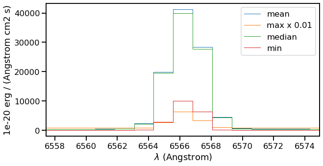

```python
fig, ax = plt.subplots(figsize=(10, 5))
hacube.mean(axis=(1, 2)).plot(label="mean")
(0.01 * hacube.max(axis=(1, 2))).plot(label="max x 0.01")
hacube.median(axis=(1, 2)).plot(label="median")
(hacube.min(axis=(1, 2))).plot(label="min")
ax.legend()
```

## Subtract the continuum

On the plus side, it looks like there is never any significant continuum slope, so we can just calculate an average continuum level to subtract:

```python
left_continuum = cube.select_lambda(6558.0, 6562.0).mean(axis=0)
right_continuum = cube.select_lambda(6572.0, 6576.0).mean(axis=0)
ha_cont = 0.5 * (left_continuum + right_continuum)
```

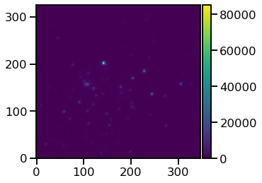

```python
ha_cont.plot(colorbar="v")
```

Promote the continuum image to a cube by taking a copy of the the line cube and pasting in new data and variance:

```python
contcube = hacube.copy()
contcube.data = np.ones_like(contcube.data) * ha_cont.data[None, :, :]
contcube.var = np.ones_like(contcube.var) * ha_cont.var[None, :, :]
```

Subtract the continuum.

```python
hacube_contsub = hacube - contcube
```

Another way of doing it would have been to just subtract `ha_cont.data[None, :, :]` from the `.data` array of `hacube`. But in that case, the `.var` would not have been propagated automatically and we would have to calculate it by hand.

Now we do the same plot:

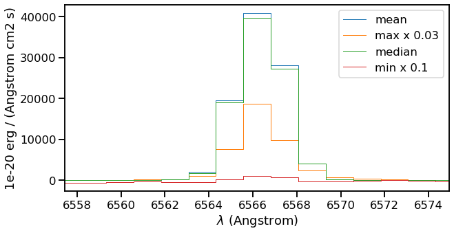

```python
fig, ax = plt.subplots(figsize=(10, 5))
hacube_contsub.mean(axis=(1, 2)).plot(label="mean")
(0.03 * hacube_contsub.max(axis=(1, 2))).plot(label="max x 0.03")
hacube_contsub.median(axis=(1, 2)).plot(label="median")
(0.1 * hacube_contsub.min(axis=(1, 2))).plot(label="min x 0.1")
ax.legend()
```

This looks good – the continuum has been eliminated in all but the min aggregation, where it goes slightly negative on the blue side, but this is probably real evidence of the underlying stellar absorption

## Make a cube of wavelengths

It is is easy to get a 1D array of the wavelengths:

```python
waves = hacube_contsub.wave.coord()
waves
```

```
array([6557.44482422, 6558.69482422, 6559.94482422, 6561.19482422,
       6562.44482422, 6563.69482422, 6564.94482422, 6566.19482422,
       6567.44482422, 6568.69482422, 6569.94482422, 6571.19482422,
       6572.44482422, 6573.69482422, 6574.94482422])
```

But there seems no built-in way to get a cube of them, so we will construct it ourselves:

```python
wavcube = hacube_contsub.clone(np.ones, np.zeros)
wavcube.data *= waves[:, None, None]
wavcube.unit = u.angstrom
wavcube.info()
```

```
[INFO] 15 x 326 x 347 Cube (no name)
[INFO] .data(15 x 326 x 347) (Angstrom), .var(15 x 326 x 347)
[INFO] center:(-72:10:32.36592575,00:59:03.15755758) size:(65.200",69.400") step:(0.200",0.200") rot:-0.0 deg frame:FK5
[INFO] wavelength: min:6557.44 max:6574.94 step:1.25 Angstrom
```

Note that we used the `.clone` method to get a new empty cube with the same coordinates, which we initialized with all ones as data and all zeros as variances (because there are no uncertainties in the wavelengths). Then we used broadcasting to multiply the data by the 1D wavelength array and set the unit correctly.

## Calculate the moments

To reduce effects noise, especially in the higher moments, we use the core window of 6562 to 6572 in between the continuum-fitting ranges

```python
hacore = hacube_contsub.select_lambda(6562.0, 6572.0)
wavcore = wavcube.select_lambda(6562.0, 6572.0)
```

The velocity moments are now trivial sums over this window.

```python
mom0 = hacore.sum(axis=0)
wav0 = 6566.5
mom1 = mom0.copy()
mom1.data = np.sum(hacore.data * (wavcore.data - wav0), axis=0) / mom0.data
# mom1.mask = mom1.mask | (mom0.data < 0.0)
```

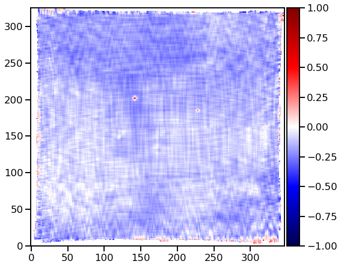

```python
fig, ax = plt.subplots(figsize=(8, 8))
mom1.plot(
    cmap="seismic",
    vmin=-1.0,
    vmax=1.0,
    colorbar="v",
)
```

## Try and deal with sky over-subtraction

Look at where Ha brightness is negative, and overlay with positions of stars (continuum is high)

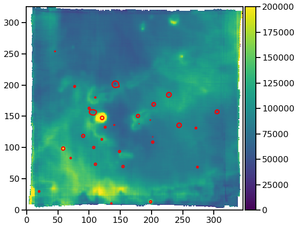

```python
fig, ax = plt.subplots(figsize=(8, 8))
mom0.plot(
    #    vmin=0.5*mom0.data.min(),
    #    vmax=0.0,
    vmin=0,
    vmax=200000,
    cmap="viridis",
    colorbar="v",
)
ax.contour(ha_cont.data, levels=[5000], colors="r")
```

We have no negative zones, so we do not need to do what we did previously. So we can ditch all this.

### Try looking at joint distribution of unnormalized moments

The unnormalized moments should behave better since they can pass through zero without having the 0/0 problem. .

#### Before correcting the sky

```python
mom0 = hacore.sum(axis=0)
mom1 = mom0.copy()
# wav0 = 6566.5
wav0 = 6566.4
mom1.data = np.sum(hacore.data * (wavcore.data - wav0), axis=0)
mom2 = mom0.copy()
mom2.data = np.sum(hacore.data * (wavcore.data - wav0) ** 2, axis=0)
```

Note that we do not divide `mom1` by `mom0`

```python
import pandas as pd
```

```python
sns.set_color_codes()
```

We mask out the brightest parts and also the outliers in velocity so that we can see the part that passes through zero better.

```python
starmask = ha_cont.data > 1e4
m = starmask | mom0.mask | (mom0.data > 2e5) | (np.abs(mom1.data) > 3e4)
df = pd.DataFrame(
    {
        "mom0": mom0.data[~m],
        "mom1": mom1.data[~m],
        "mom2": mom2.data[~m],
    }
)
df.describe()
```

|  | mom0 | mom1 | mom2 |
| --- | --- | --- | --- |
| count | 103762.000000 | 103762.000000 | 103762.000000 |
| mean | 94123.653509 | -3199.731497 | 114528.578831 |
| std | 24211.288112 | 5853.147911 | 32483.353119 |
| min | 155.729950 | -29977.257946 | 3580.284387 |
| 25% | 75750.775904 | -6984.423162 | 91181.638545 |
| 50% | 90246.720074 | -3470.419445 | 109041.784207 |
| 75% | 109306.269383 | 423.243303 | 133044.887796 |
| max | 199961.744850 | 29966.770132 | 579072.503091 |

Make a corner plot of the moment distributions:

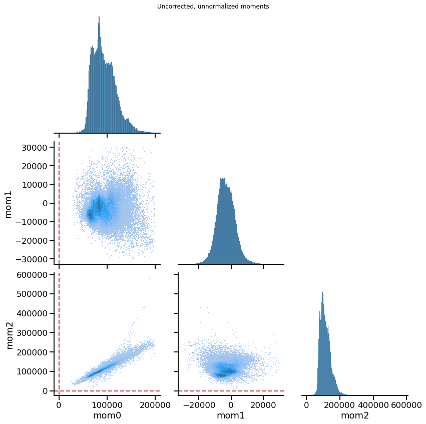

```python
g = sns.pairplot(
    df,
    kind="hist",
    height=4,
    corner=True,
)
g.axes[1, 0].axvline(0.0, color="r", linestyle="dashed")
g.axes[2, 0].axvline(0.0, color="r", linestyle="dashed")
g.axes[2, 0].axhline(0.0, color="r", linestyle="dashed")
g.axes[2, 1].axhline(0.0, color="r", linestyle="dashed")
g.fig.suptitle("Uncorrected, unnormalized moments")
g.tight_layout()
```

Note that for an emission line, mom0 and mom2 should be positive definite. They are now, so that is good.

#### (What used to be) After correcting the sky

**We do not need to do this any more really.**

I have removed everything that creates the underscore-prefixed variables, and then swap back the original variables in the plots

We take a less restrictive mask, only masking out the outliers in any of the moments:

```python
m = (
    starmask
    | mom0.mask
    | (mom0.data > 45e4)
    | (mom1.data < -3e4)
    | (mom1.data > 3e4)
    | (mom2.data < 0)
    | (mom2.data > 4.5e5)
)
df = pd.DataFrame(
    {
        "mom0": mom0.data[~m],
        "mom1": mom1.data[~m],
        "mom2": mom2.data[~m],
    }
)
df.describe()
```

|  | mom0 | mom1 | mom2 |
| --- | --- | --- | --- |
| count | 104003.000000 | 104003.000000 | 104003.000000 |
| mean | 94443.018127 | -3204.803783 | 114885.939026 |
| std | 25121.863592 | 5878.441205 | 33323.660320 |
| min | 155.729950 | -29977.257946 | 3580.284387 |
| 25% | 75793.400496 | -6993.021195 | 91225.355128 |
| 50% | 90338.302082 | -3474.037219 | 109122.193588 |
| 75% | 109434.401069 | 426.173757 | 133216.683938 |
| max | 350990.716995 | 29966.770132 | 449348.469172 |

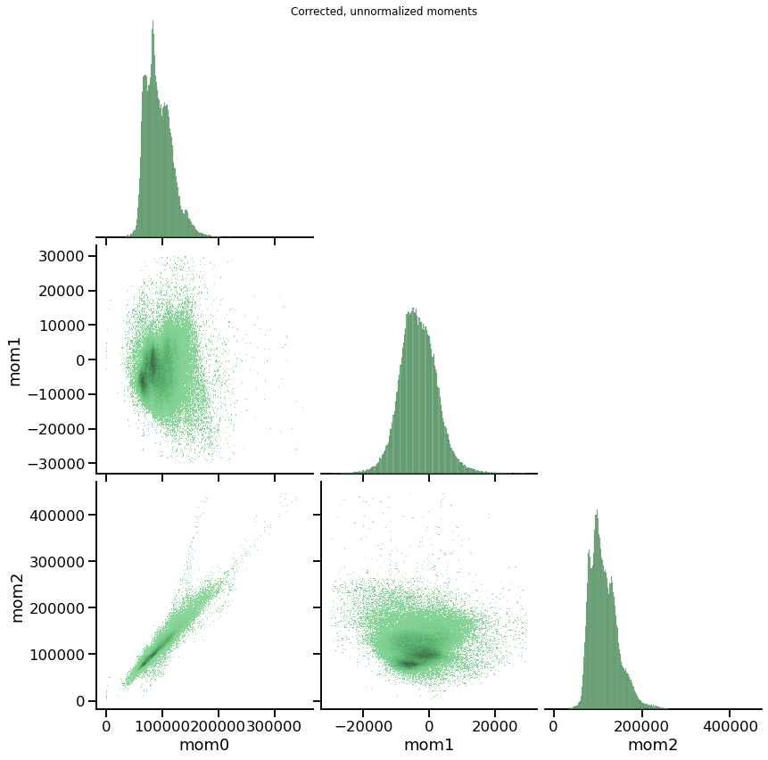

```python
g = sns.pairplot(
    df,
    kind="hist",
    height=4,
    corner=True,
    plot_kws=dict(color="g"),
    diag_kws=dict(color="g"),
)
g.fig.suptitle("Corrected, unnormalized moments")
g.tight_layout(pad=0)
```

So that looks like it has worked. Note that mom1 fans out as a triangle as mom0 increases, but it stays roughly centered on zero. This is because of the judicious adjustment to wav0 above.

#### Back to normalized moments again

If that is sorted, then we should be able to look at the normalized moments:

```python
mom0 = hacore.sum(axis=0)
mom1 = mom0.copy()
mom1.data = np.sum(hacore.data * (wavcore.data - wav0), axis=0) / mom0.data
mom2 = mom0.copy()
mom2.data = (
    np.sum(hacore.data * (wavcore.data - wav0 - mom1.data) ** 2, axis=0) / mom0.data
)
```

```python
m = (
    starmask
    | mom0.mask
    | (mom0.data < 1.6e4)
    | (mom0.data > 45e4)
    | (mom1.data < -0.4)
    | (mom1.data > 0.4)
    | (mom2.data > 1.75)
    | (mom2.data < 0.5)
)
KMS_PER_ANGSTROM = 3e5 / 6563.0
df2 = pd.DataFrame(
    {
        "log10 I(Ha)": np.log10(mom0.data[~m]),
        "V(Ha)": mom1.data[~m] * KMS_PER_ANGSTROM,
        "sig(Ha)": np.sqrt(mom2.data[~m]) * KMS_PER_ANGSTROM,
    }
)
df2.describe()
```

|  | log10 I(Ha) | V(Ha) | sig(Ha) |
| --- | --- | --- | --- |
| count | 104099.000000 | 104099.000000 | 104099.000000 |
| mean | 4.961475 | -1.723582 | 50.189127 |
| std | 0.111359 | 2.939280 | 1.791330 |
| min | 4.399554 | -17.672241 | 32.555877 |
| 25% | 4.879841 | -3.759695 | 49.154460 |
| 50% | 4.956180 | -1.750153 | 50.027146 |
| 75% | 5.039531 | 0.210924 | 51.110783 |
| max | 5.653209 | 18.257389 | 60.353160 |

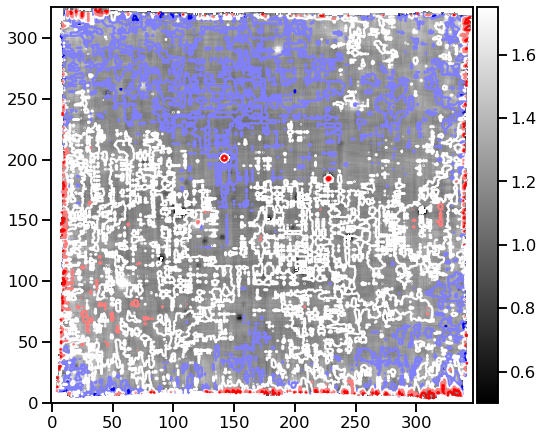

```python
fig, ax = plt.subplots(figsize=(8, 8))
mom2.mask = mom2.mask | m
mom2.plot(
    cmap="gray",
    vmin=0.5,
    vmax=1.75,
    colorbar="v",
)
ax.contour(KMS_PER_ANGSTROM * mom1.data, levels=[-10, -5, 0, 5, 10], cmap="bwr")
```

## Redo it all using my moments library

Lots of the above can be done more easily now:

```python
mom6563 = moments.find_moments(hacore)
```

```python
mom6563[0].info()
```

```
[INFO] 326 x 347 Image (/Users/will/Work/Muse-Hii-Data/SMC-NGC-346/PeterZeidler/DATACUBE_FINAL_fwhm_cor.fits)
[INFO] .data(326 x 347) (1e-20 erg / (Angstrom cm2 s)), .var(326 x 347)
[INFO] center:(-72:10:32.36592575,00:59:03.15755758) size:(65.200",69.400") step:(0.200",0.200") rot:-0.0 deg frame:FK5
```

```python
mom_pars_6563 = dict(
    restwav=6562.79,
    irange=[3.0e4, 1.0e6],
    vrange=[150, 180],
    srange=[40, 60],
)
```

```python
moments.save_moments_to_fits(
    mom6563,
    label="6563",
    flabel="ngc346-PZ-hi",
    **mom_pars_6563,
)
```

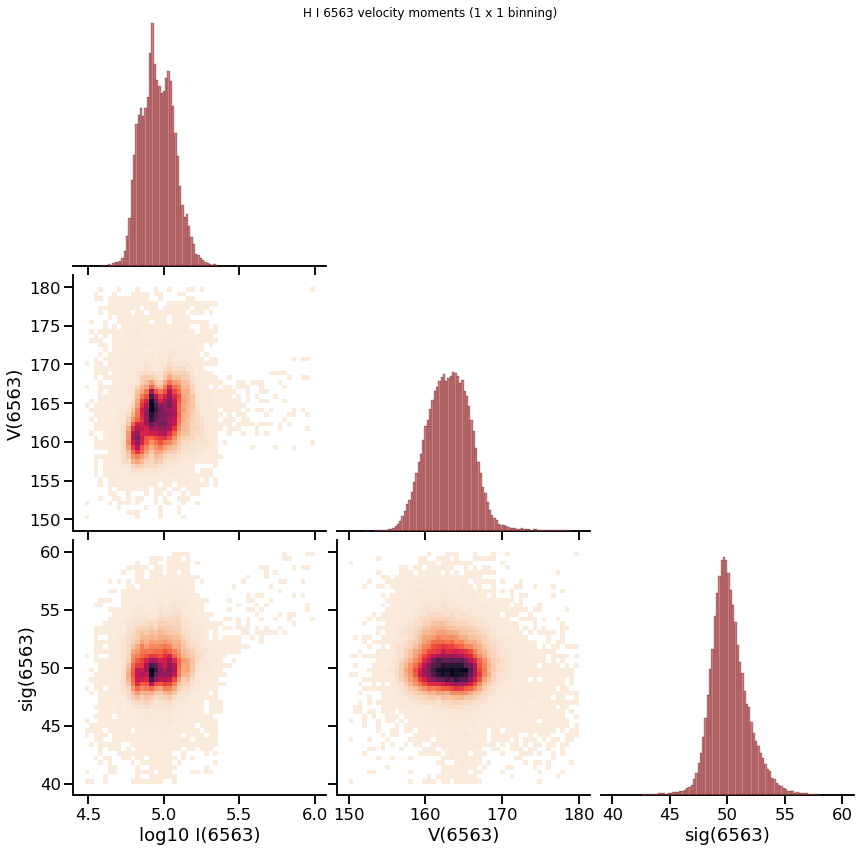

```python
plot_pars_6563 = dict(
    ilabel="H I",
    label="6563",
    flabel="ngc346-PZ-hi",
    **mom_pars_6563,
)
g = moments.moments_corner_plot(mom6563, rebin=1, **plot_pars_6563)
```

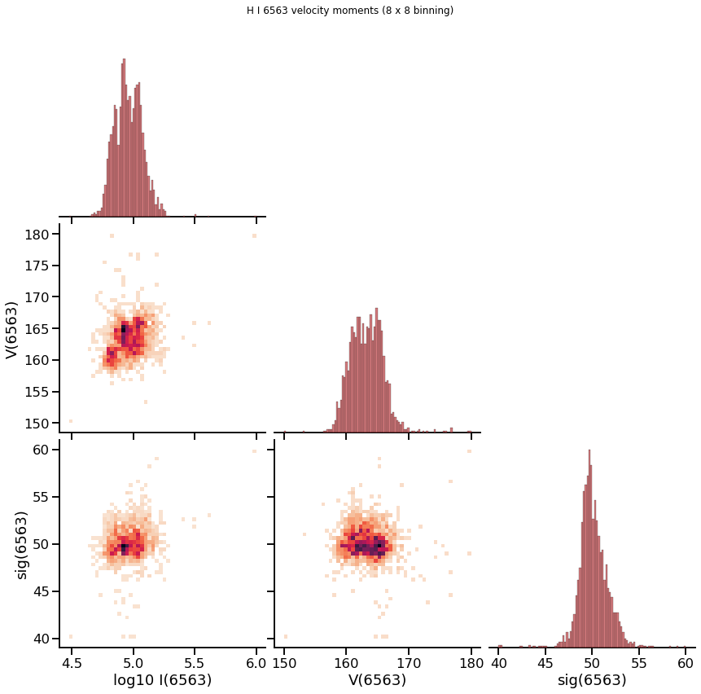

```python
g = moments.moments_corner_plot(mom6563, rebin=8, **plot_pars_6563)
```

So, these results look a bit more "boring" than the ones from the ESO cube, but they are probably more reliable.

The range of velocities is reduced and the width does not show any significant change with velocity.